# *Data wrangling* y *EDA* del *data set* de Netflix

Manel Hoffmann Quintana, Joaquín Martín Castillo y Jordi Vanrell Forteza

2020-12-23

[figure not shown]

# Primera parte: Contexto y datos

## Contexto y fuente de los datos

Los datos de partida proceden de una competición de [Kaggle](https://www.kaggle.com/netflix-inc/netflix-prize-data) encaminada a emular, con los mismos datos, el concurso abierto para el sistema de recomendación de películas de **Netflix**.

Los ficheros suministrados son los que siguen:

- `movie_titles.csv`, un directorio de los títulos, años de estreno y códigos numéricos de las 17770 películas disponibles.
- 4 ficheros `.txt` con el formato `combined_data_X.txt`, que incluyen las puntuaciones de los usuarios (codificados con un número) y la fecha en que se emitieron para cada película. Estos cuatro archivos contendrían la información necesaria para modelizar el sistema de recomendaciones, aunque aquí su uso se limitará al análisis descriptivo.
- `probe.txt` y `qualifying.txt`, útiles únicamente para testar un sistema de recomendación. Se obviarán porque este no es el objeto del presente estudio.

## Tratamiento de datos

Los ficheros `combined_data_X.txt` se presentan con una estructura casi rectangular. Tras una fila inicial con el código de la película seguido de **:** se listan el código de cada cliente, su puntuación a esa película y la fecha en que se emitió la valoración.

**Tabla 1: Estructura**

| V1 |
| --- |
| 1: |
| 1488844,3,2005-09-06 |
| 822109,5,2005-05-13 |

El primer objetivo de la manipulación de las tablas es conseguir una verdadera estructura rectangular, estableciendo el código de la película como una variable más para cada valoración emitida (y descartando luego las filas donde figuraban los códigos de las películas).

A continuación, y de acuerdo con las indicaciones dadas en el enunciado de este taller, se extrae una muestra de 250 películas al azar de los ficheros `combined_data_X.txt`. La semilla aleatoria se establece en 247177.

Posteriormente se importa el archivo `movie_titles.csv` y se fusiona con la selección anterior utilizando el identificador numérico de la película como clave común.

Por último, se exporta el resultado a un archivo `.csv`.

# Segunda parte: Análisis exploratorio (EDA)

## 1. Lectura y análisis preliminar de variables

Recapitulando, se dispone de un *data set* con las siguientes variables:

- `ID_film` y `Title` son las variables de identificación de las películas. La primera es una cifra sin ningún valor numérico, no hace referencia a los IMDB reales. La segunda representa el título en formato *string*. Ambas deben tratarse como variables cualitativas politómicas nominales: permiten una identificación de un valor pero se excluye la posibilidad de ordenación.
- `Year` contiene los años de estreno de las películas. Dependiendo del uso que quiera darse a la variable se considera como un factor o incluso un factor ordenado en base al tiempo. Sin embargo, también podría entenderse como una variable cuantitativa discreta: permite operar con sus valores pero no admite valores intermedios.
- `ID_user` es la variable de identificación del usuario, una codificación anónima sin ningún valor numérico. Debería tratarse como una variable cualitativa politómica nominal.
- `Score` representa las puntuaciones otorgadas por los usuarios a las películas, codificadas en enteros de 1 a 5, donde 1 representa la puntuación mínima (muy insatisfactoria en la escala de Likert), 3 una puntuación neutral y 5 la máxima (muy satisfactoria). Puede entenderse como un factor ordenado pero también como variable numérica, dependiendo del análisis que quiera efectuarse.
- `Rating_date` contiene las fechas en que los usuarios puntuaron las películas. Es una variable de tipo fecha y, al igual que `Year` podría verse como factor, factor ordenado o variable cuantitativa discreta en la medida en que en su operatividad no admite valores intermedios y suele emplear escalas de razón.

Teniendo en cuenta la abundancia de variables cualitativas, primero se carga el *data set* y a continuación se transforman las variables que lo requieren.

Cabe decir que la columna `X1` se corresponde con la numeración de las filas de Python y, como tal, es prescindible.

**Tabla 2: Datos estructurados**

| ID_film | Year | Title | ID_user | Score | Rating_date |
| --- | --- | --- | --- | --- | --- |
| 10 | 2001 | Fighter | 699878 | 2 | 2004-02-09 |
| 10 | 2001 | Fighter | 2625420 | 2 | 2005-03-17 |
| 10 | 2001 | Fighter | 1874659 | 5 | 2003-11-18 |

## 2. Distribución del número de películas por año

Se ha usado la Regla de Scott para determinar el número de clases (9) y se han representado las observaciones en un histograma. En el eje de abscisas se representan los intervalos temporales y en el eje de ordenadas el número de estrenos.

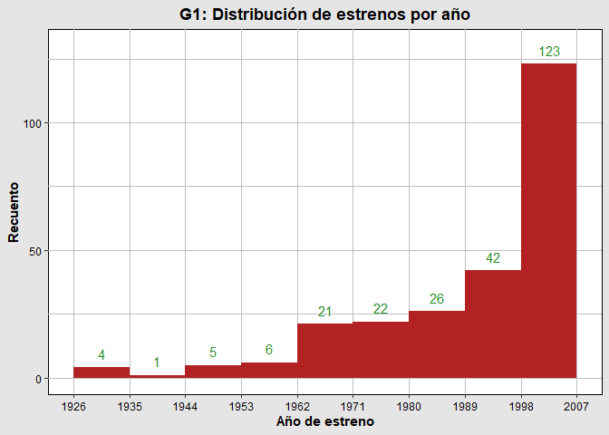

Como puede observarse, el número de estrenos es más abundante en los periodos más cercanos en el tiempo. Casi la mitad de las películas de la muestra son más o menos contemporáneas al periodo que abarcan las valoraciones de los usuarios.

## 3. La librería `lubridate`

Esta librería permite la desagregación de la variable presente en formato fecha, `Rating_date`, en sus componentes año, mes, semana del año y también día de la semana. Con todo, se incorporan como nuevas variables a la base de datos para trabajar posteriormente con ellas.

## 4. Estadísticos principales

Se resumen los estadísticos principales de la variable *Score* por película. En concreto se recogen `count` (el número de valoraciones), `points` (el total de puntos acumulados), `mean` (la media aritmética de las valoraciones), `stdev` (su desviación típica), `mode` (la valoración más frecuente), `min` (la valoración mínima), `p25` (el primer cuartil de las valoraciones), `median` (la mediana o segundo cuartil), `p75` (el tercer cuartil de las valoraciones) y `max` (la valoración máxima).

En la tabla figuran las 5 películas más populares.

**Tabla 3: Estadísticos principales**

| Title | count | points | mean | stdev | mode | min | p25 | median | p75 | max |
| --- | --- | --- | --- | --- | --- | --- | --- | --- | --- | --- |
| Mystic River | 143682 | 554864 | 3.86 | 0.93 | 4 | 1 | 3 | 4 | 5 | 5 |
| The Butterfly Effect: Director’s Cut | 109385 | 403496 | 3.69 | 1.06 | 4 | 1 | 3 | 4 | 4 | 5 |
| Harry Potter and the Sorcerer’s Stone | 106238 | 434695 | 4.09 | 0.95 | 5 | 1 | 4 | 4 | 5 | 5 |
| Love Actually | 101118 | 373513 | 3.69 | 1.05 | 4 | 1 | 3 | 4 | 4 | 5 |
| X2: X-Men United | 98720 | 388187 | 3.93 | 0.89 | 4 | 1 | 3 | 4 | 5 | 5 |

Cabe señalar que, entre las películas de la muestra, hay alguna con varias modas.

## 5. Distribución y estadísticos de las 5 películas más populares

Se representan los estadísticos del apartado anterior para ilustrar la distribución de las valoraciones, por separado mediante histogramas y en conjunto con un boxplot. Asimismo, en este último, se ilustra también la media aritmética y el alcance de la desviación típica.

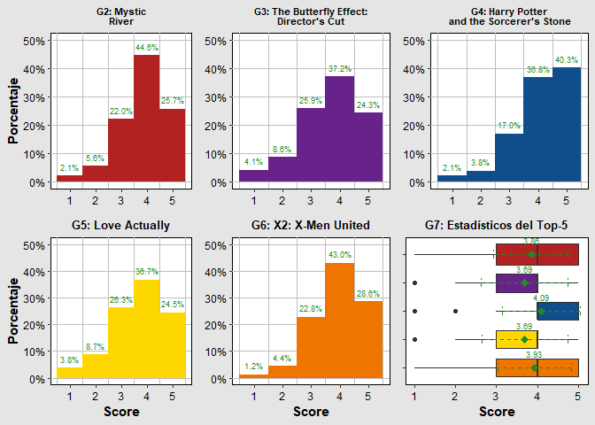

## 6. Distribución de las valoraciones por mes y día de la semana

A partir de las variables generadas en el punto 3 se agrupan los datos, por día de la semana y, por separado, según mes del año. De acuerdo con los resultados, los días de la semana en que se valoran más películas son martes y lunes. En cuanto a los meses del año, parece ser que los meses en que se emiten más valoraciones son julio y agosto.

Sirva para ilustrarlo este mapa de calor:

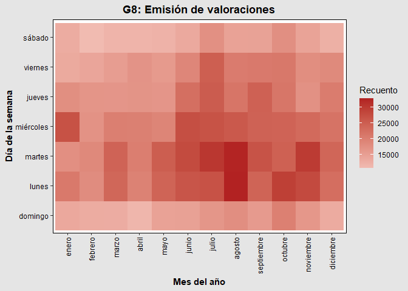

Analizando las dos variables de manera conjunta se aprecia que los lunes y martes de agosto son los días en que se emiten más valoraciones. También se observa que los usuarios puntúan más películas durante el segundo semestre del año, en especial los primeros días laborables de la semana.

## 7. Valoraciones por película y año

Se pretende conocer las valoraciones por año que reciben las 10 películas más populares. Tras la agrupación de los datos por película y año de valoración se desagregan según esta última.

**Tabla 4: Recuento anual de valoraciones de las 10 películas más populares**

| Title | 1999 | 2000 | 2001 | 2002 | 2003 | 2004 | 2005 |
| --- | --- | --- | --- | --- | --- | --- | --- |
| A.I. Artificial Intelligence | 0 | 0 | 327 | 8567 | 10963 | 14744 | 21009 |
| Harry Potter and the Sorcerer’s Stone | 0 | 0 | 40 | 11005 | 16025 | 27529 | 51639 |
| Love Actually | 0 | 0 | 0 | 0 | 214 | 52210 | 48694 |
| Matchstick Men | 0 | 0 | 0 | 0 | 129 | 55809 | 42064 |
| Mystic River | 0 | 0 | 0 | 0 | 176 | 74157 | 69349 |
| Once Upon a Time in Mexico | 0 | 0 | 0 | 0 | 205 | 38938 | 11905 |
| The Butterfly Effect: Director’s Cut | 0 | 0 | 0 | 0 | 0 | 52305 | 57080 |
| The Cider House Rules | 0 | 1136 | 2943 | 7726 | 9001 | 13287 | 20051 |
| The Mask of Zorro | 2 | 1172 | 2628 | 2707 | 6628 | 11586 | 24217 |
| X2: X-Men United | 0 | 0 | 0 | 0 | 10489 | 47602 | 40629 |

El gráfico **G9** presenta los resultados de la Tabla 4 de manera visual. Se percibe con claridad el incremento de la popularidad de *Netflix* a partir del cambio de siglo, y especialmente desde 2002, año en el que empieza a cotizar en bolsa.

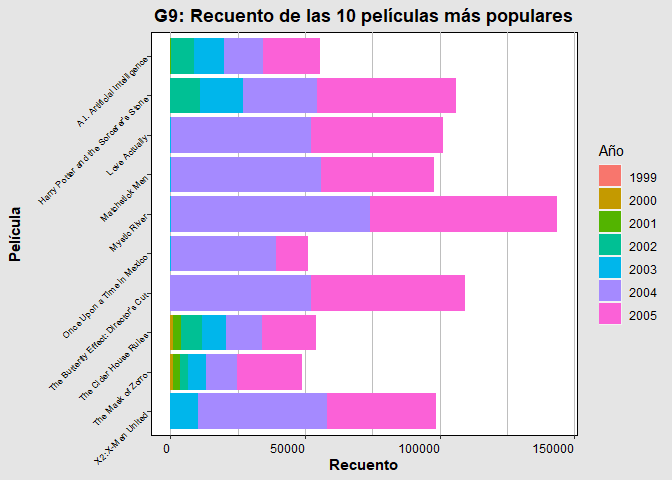

## 8. Evolución del *score* promedio de las 10 películas más populares

Quiere estudiarse la evolución del promedio de las valoraciones de las 10 películas más populares. Para ello se extrae la media de los datos por película y año de valoración y se representan en un gráfico de líneas. A continuación se hace lo propio con la media acumulada para cada día del rango temporal estudiado con el fin de ilustrar la posición de la media aritmética en cada momento del tiempo.

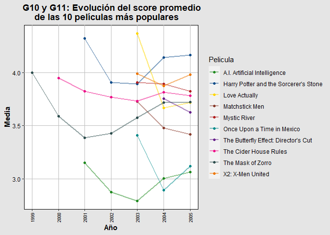

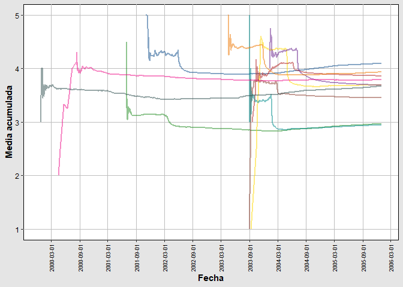

Se aprecia que el *score* de la mayoría de películas representadas se sitúa entre valores cercanos a 3 y 4. Solamente el de *Harry Potter and the Sorcerer’s Stone* se encuentra por encima de 4 al final del periodo estudiado.

## 9. Similitud coseno para los usuarios más activos

En este último apartado se pretenden estudiar superficialmente las características de los usuarios más involucrados en la emisión de valoraciones (se contemplan aquellos que han puntuado más de 75 películas). Para ello se explota la información implícita en las valoraciones de las películas. En concreto, se desea generar una medida de similaridad entre usuarios basada en sus gustos que, en un grado de desarrollo mayor, podría ser la semilla de un sistema de recomendación de películas.

La medida de similaridad escogida es la **similitud coseno** que, para cada par *i, k* de vectores de valoraciones ($t$ y $u$) de las películas en la base de datos, cumple:

$$\cos(v)_{i,k}=\frac{\sum_{i,k=1}^n t_i\cdot u_k}{\sqrt{\sum_{i=1}^n t_i^2}\cdot \sqrt{\sum_{k=1}^n u_k^2}}$$

Los valores $\cos(v)_{i,k}$ generados se almacenan en una matriz cuadrada, ocupando las posiciones *i, k* para luego representarse en un mapa de calor con un dendrograma integrado que agrupa a los usuarios según su grado de semejanza. Valores más altos de $\cos(v)_{i,k}$ representan similitudes más elevadas.

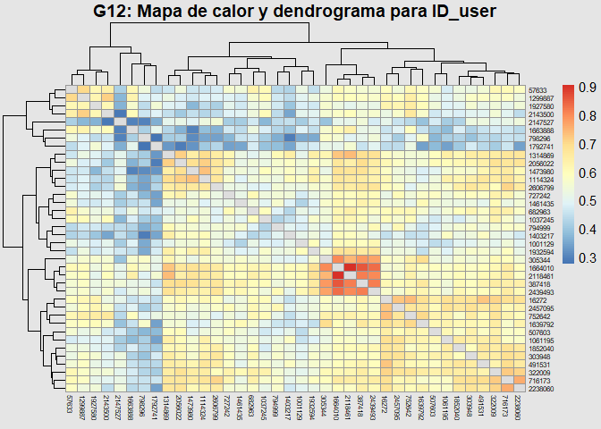